# DivEMT: Neural Machine Translation Post-Editing Effort Across Typologically Diverse Languages

Antonio Toral

Generation date: giu 21, 2022 - 15:09:11

This is partially based on a previous analysis for the publication: Toral, A., Wieling, M., and Way, A. (2018, in press). Post-editing effort of a novel with statistical and neural machine translation. Frontiers in Digital Humanities.

Variables used

- Predictors
  - Fixed
    - Length of the source sentence (characters better than words according to the 2018 paper)
    - task_type: the translation condition. It is a factor with 3 levels: HT (human translation from scratch), PE1 (post-editing the output of Google Translate) and PE2 (post-editing the output of mBART50). The reference level is HT.
    - trial number
    - language (6 languages)
  - Random factors
    - Subject (18 translators)
    - Item (nested). Document (107 documents) / Sentence (413 sentences)
- Dependent variables
  - Translation time in seconds (temporal effort)
  - number of keystrokes (technical effort)
  - number of pauses | avg length of pauses | pause to total time ratio (cognitive effort)
- Hypothesised interactions
  - trial * task_type: does the longitudinal effect depend on translation type?
  - lang_id * task_type: does the effect of translation type vary per language?
  - len_sl_char * task_type: does translation speed of sentences of different length depend on translation type? Some translators said post-editing is useful only for short sentences. In the 2018 paper post-editing of NMT (RNN) was less effective for long sentences.
- Hypothesised random slopes
  - 1+trial|subject -> longitudinal effect depends on the subject
  - 1+task_type|subject -> effect of translation mode depends on subject. MT suggestions may help some translators more than others.
  - 1+task_type|item -> effect of translation mode depends on sentence. MT quality varies across sentences.

# 1 Load libraries and install required packages if not installed yet

```r
# install packages if not there yet
packages <- c("car", "effects", "ggplot2", "jtools", "lme4", "lmerTest", "mgcv", "optimx", "tidyr")
if (length(setdiff(packages, rownames(installed.packages()))) > 0) {
    install.packages(setdiff(packages, rownames(installed.packages())), repos = "http://cran.us.r-project.org")
}

library(car)
library(effects)
library(ggplot2)
library(jtools)
library(lme4)
library(mgcv)
library(optimx)
library(interactions)
```

```r
# display version information
R.version.string
```

```
## [1] "R version 4.2.0 (2022-04-22)"
```

```r
packageVersion('mgcv')
```

```
## [1] '1.8.40'
```

```r
packageVersion('car')
```

```
## [1] '3.0.13'
```

```r
packageVersion('lme4')
```

```
## [1] '1.1.29'
```

```r
packageVersion('mgcv')
```

```
## [1] '1.8.40'
```

```r
packageVersion('optimx')
```

```
## [1] '2022.4.30'
```

# 2 Load dataset

```r
setwd("~/projects/divemt/data/processed")
# Save the filtered_data variable produced in the analysis.ipynb notebook to load it here.
mydf <- read.csv("filtered_divemt.tsv", sep="\t")
# 7434 rows (18 translators * 413 sentences)
# Outliers have been already removed from this dataset (17 sentences for all languages)
# create additional variables (trial number, time and number of keystrokes per character, seconds per keystrokes and words per hour)
mydf$trial <- mydf$per_subject_visit_order

mydf$time <- mydf$event_time / 1000 # time from ms to seconds
mydf$time_h = mydf$time / 3600 # time from seconds to hours

mydf$time_div_sl_len_char = mydf$time / mydf$src_len_chr # time per character
mydf$k_total_div_sl_len_char = mydf$k_total / mydf$src_len_chr # keystrokes per character
mydf$k_total_div_time = mydf$k_total / mydf$time # keystrokes per second
mydf$sl_len_word_div_time_hours = mydf$src_len_wrd / (mydf$time_h) # words per hour

# scale the continuous predictors
mydf$src_len_chr.s <- scale(mydf$src_len_chr)
mydf$src_len_chr.s = c(mydf$src_len_chr.s)
mydf$trial.s <- scale(mydf$trial)
mydf$trial.s = c(mydf$trial.s)

# relevel predictor language. Use as reference the slowest one (Ukrainian)
mydf$lang_id <- as.factor(mydf$lang_id)
mydf$lang_id <- relevel(mydf$lang_id, "ukr")

# document_id as a factor, since it'll be used as a random factor
mydf$document_id <- as.factor(mydf$doc_id)
```

# 3 Overall Relative Changes (PE with MT1 and MT2 compared to HT)

Productivity (words processed per hour)

```r
product_per_task_type <- tapply(mydf$src_len_wrd, mydf$task_type, FUN=sum) / tapply(mydf$time/3600, mydf$task_type, FUN=sum) #productivity: words/hour
product_per_task_type
```

```
##       ht      pe1      pe2
## 553.5960 898.7046 721.9148
```

```r
for (i in seq(2,3)){
  print((product_per_task_type[i] - product_per_task_type[1]) / product_per_task_type[1])
}
```

```
##       pe1
## 0.6233942
##       pe2
## 0.3040462
```

Relative changes in productivity: MT1 62%, MT2 30% (in IT: MT1 101%, MT2 74%)

Temporal effort (seconds per source character)

```r
temp_eff_per_task_type <- tapply(mydf$time, mydf$task_type, FUN=sum) / tapply(mydf$src_len_chr, mydf$task_type, FUN=sum) # temp effort: seconds/character
temp_eff_per_task_type
```

```
##        ht       pe1       pe2
## 1.0743122 0.6617691 0.8238298
```

```r
for (i in seq(2,3)){
  print((temp_eff_per_task_type[i] - temp_eff_per_task_type[1]) / temp_eff_per_task_type[1])
}
```

```
##        pe1
## -0.3840067
##       pe2
## -0.233156
```

Temporal reduction: MT1 -38%, MT2 -23% (in IT: MT1 -51%, MT2 -43%)

Technical effort (keystrokes per source character)

```r
tech_eff_per_task_type <- tapply(mydf$k_total, mydf$task_type, FUN=sum) / tapply(mydf$src_len_chr, mydf$task_type, FUN=sum) # technical effort: keystrokes/character
tech_eff_per_task_type
```

```
##        ht       pe1       pe2
## 1.7135328 0.7636151 1.0437751
```

```r
for (i in seq(2,3)){
  print((tech_eff_per_task_type[i] - tech_eff_per_task_type[1]) / tech_eff_per_task_type[1])
}
```

```
##        pe1
## -0.5543621
##        pe2
## -0.3908636
```

Keystroke reduction: MT1 -55%, MT2 -39% (in IT MT1 -77%, MT2 -70%)

Typing speed (keystrokes per second)

```r
type_speed_per_task_type <- tapply(mydf$k_total, mydf$task_type, FUN=sum) / tapply(mydf$time, mydf$task_type, FUN=sum) # keystrokes/second
type_speed_per_task_type
```

```
##       ht      pe1      pe2
## 1.595005 1.153900 1.266979
```

```r
for (i in seq(2,3)){
  print((type_speed_per_task_type[i] - type_speed_per_task_type[1]) / type_speed_per_task_type[1])
}
```

```
##       pe1
## -0.276554
##        pe2
## -0.2056581
```

MT1 -27%, MT2 -21% (in IT MT1 -55%, MT2 -48%)

# 4 Temporal Effort

## 4.1 Outliers

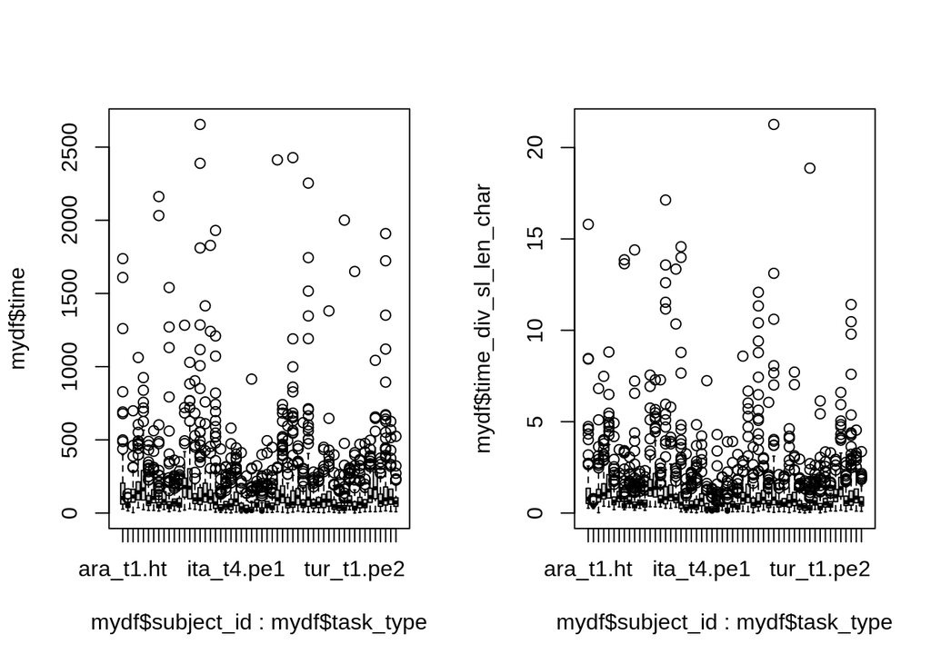

```r
# 1 boxplot per subject and task
par(mfrow=c(1,2), family  = "Arial")
boxplot(mydf$time ~ mydf$subject_id + mydf$task_type)
boxplot(mydf$time_div_sl_len_char ~ mydf$subject_id + mydf$task_type)#, ylim=c(0, 40))
```

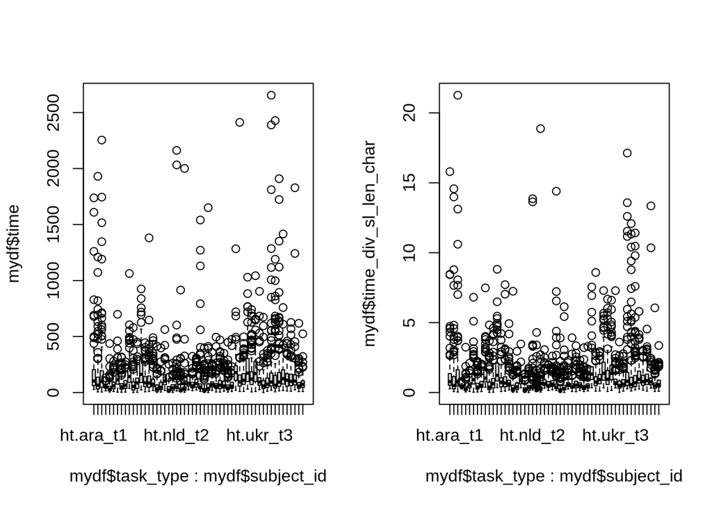

```r
# 1 boxplot per task and subject
par(mfrow=c(1,2), family  = "Arial")
boxplot(mydf$time ~ mydf$task_type + mydf$subject_id)
boxplot(mydf$time_div_sl_len_char ~ mydf$task_type + mydf$subject_id)#, ylim=c(0, 40))
```

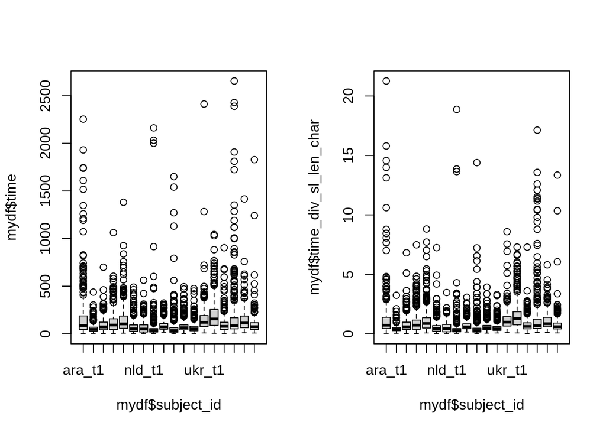

```r
# 1 boxplot per subject
par(mfrow=c(1,2), family  = "Arial")
boxplot(mydf$time ~ mydf$subject_id)
boxplot(mydf$time_div_sl_len_char ~ mydf$subject_id)#, ylim=c(0, 40))
```

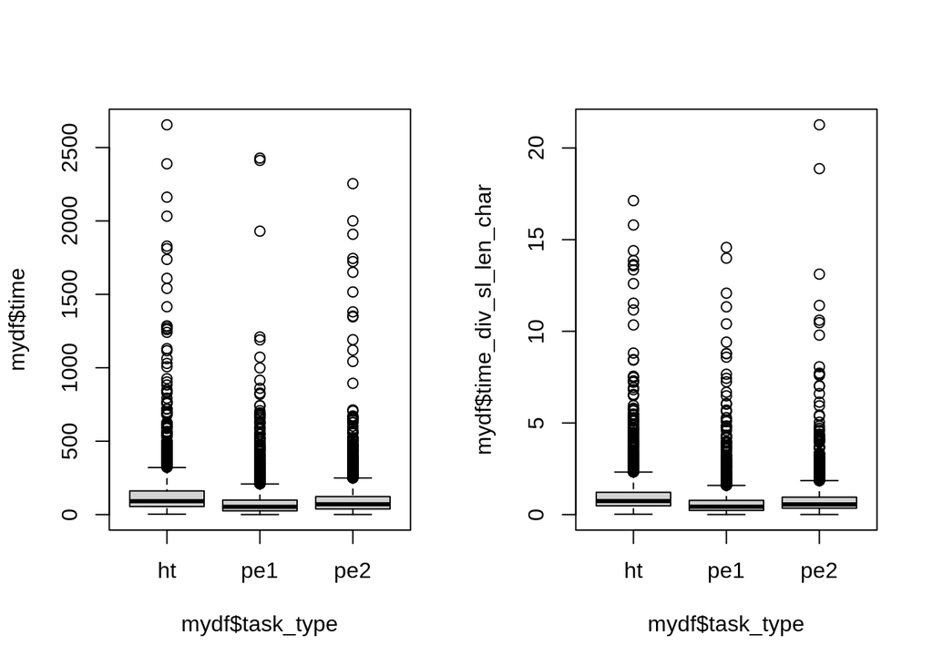

```r
# 1 boxplot per task
par(mfrow=c(1,2), family  = "Arial")
boxplot(mydf$time ~ mydf$task_type)
boxplot(mydf$time_div_sl_len_char ~ mydf$task_type)#, ylim=c(0, 40))
```

## 4.2 Dependent Variable Transformation

The dependent variable (translation time) has a very long right tail. Hence we transform it logarithmically.

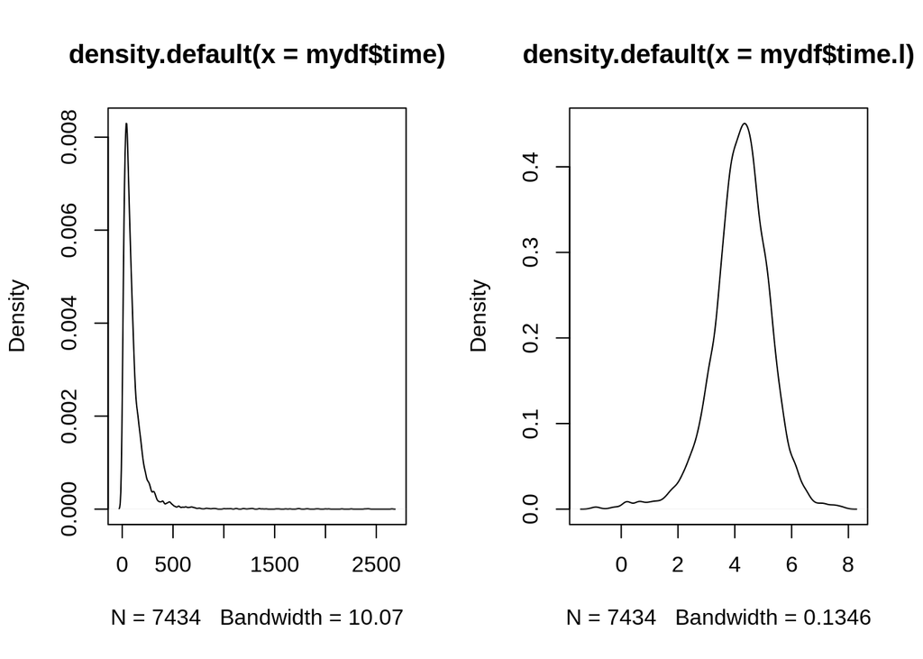

```r
mydf$time.l <- log(mydf$time)
par(mfrow=c(1,2), family  = "Arial")
plot(density(mydf$time))
plot(density(mydf$time.l))
```

## 4.3 LMER: Nested Random Effect

```r
te.lmer0 = lmer(time.l ~ src_len_chr.s + (1|subject_id) + (1|item_id), mydf, REML=T)
summary(te.lmer0)
```

```
## Linear mixed model fit by REML ['lmerMod']
## Formula: time.l ~ src_len_chr.s + (1 | subject_id) + (1 | item_id)
##    Data: mydf
##
## REML criterion at convergence: 18160.8
##
## Scaled residuals:
##     Min      1Q  Median      3Q     Max
## -6.5199 -0.5048  0.0279  0.5484  5.1058
##
## Random effects:
##  Groups     Name        Variance Std.Dev.
##  item_id    (Intercept) 0.09365  0.3060
##  subject_id (Intercept) 0.20613  0.4540
##  Residual               0.61835  0.7864
## Number of obs: 7434, groups:  item_id, 413; subject_id, 18
##
## Fixed effects:
##               Estimate Std. Error t value
## (Intercept)    4.21448    0.10845   38.86
## src_len_chr.s  0.37702    0.01761   21.41
##
## Correlation of Fixed Effects:
##             (Intr)
## src_ln_chr. 0.000
```

```r
te.lmer0b = lmer(time.l ~ src_len_chr.s + (1|subject_id) + (1|document_id/item_id), mydf, REML=T)
summary(te.lmer0b)
```

```
## Linear mixed model fit by REML ['lmerMod']
## Formula: time.l ~ src_len_chr.s + (1 | subject_id) + (1 | document_id/item_id)
##    Data: mydf
##
## REML criterion at convergence: 18112.3
##
## Scaled residuals:
##     Min      1Q  Median      3Q     Max
## -6.4845 -0.5063  0.0271  0.5514  5.0226
##
## Random effects:
##  Groups              Name        Variance Std.Dev.
##  item_id:document_id (Intercept) 0.05357  0.2315
##  document_id         (Intercept) 0.04006  0.2001
##  subject_id          (Intercept) 0.20614  0.4540
##  Residual                        0.61835  0.7864
## Number of obs: 7434, groups:
## item_id:document_id, 413; document_id, 107; subject_id, 18
##
## Fixed effects:
##               Estimate Std. Error t value
## (Intercept)    4.21711    0.10977   38.42
## src_len_chr.s  0.38088    0.01673   22.77
##
## Correlation of Fixed Effects:
##             (Intr)
## src_ln_chr. 0.000
```

```r
AIC(te.lmer0) - AIC(te.lmer0b) # 46.5 (nested random effect makes sense)
```

```
## [1] 46.49657
```